# RPPA

Ruixi Li

2023-11-26

```r
library(readr)
library(tidyverse)
library(caret)
library(randomForest)
library(purrr)
library(skimr)
library(party)
```

# Data Preparation

## Outcome

### Clean CRISPR data

```r
# load CRISPR data
CRISPR = read_csv("data/gene_dependency_corrected.csv") |>
  rename(dep_map_id = line)
# 558 cell lines x 17,634 genes

# remove the numbers following the gene names
colnames(CRISPR) = gsub(" \\(.*\\)", "", colnames(CRISPR))

# load cellmatch data(I separate the data in excel and rename the file as "cellline_match.cvs")
cell_match = read_csv("data/DepMap-2019q1-celllines_v2.csv") |>
  janitor::clean_names() |>
  select(1,2) |> rename(ccle_id = ccle_name)

# replace ccle_id with dep_map_id
CRISPR_match = left_join(CRISPR, cell_match, by='dep_map_id') |> select(-dep_map_id) |>
  select(ccle_id, everything())
```

### clean shRNA

```r
shRNA = read_csv("data/D2_combined_gene_dep_scores.csv") |>
  pivot_longer(cols = -1,
               names_to = "ccle_id") |>
  pivot_wider(
    names_from = 1
  )
# 712 cell lines X 17310 genes

# remove the numbers following the gene names
colnames(shRNA) = gsub(" \\(.*\\)", "", colnames(shRNA))
```

# Figure 3

## Fig 3 A-B

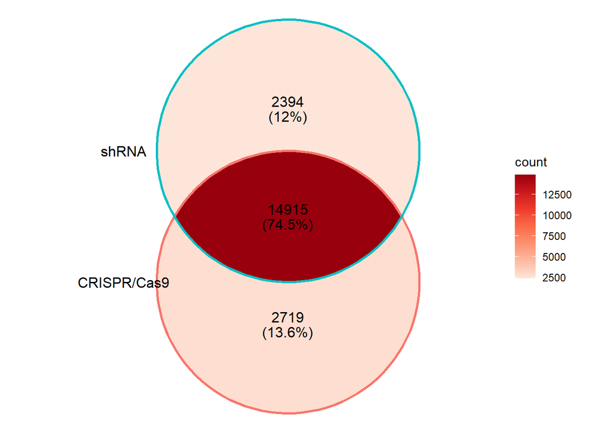

```r
library(ggVennDiagram)
library(grid)

genes_crispr = names(CRISPR)[-1]  # Replace with actual gene names from CRISPR/Cas9 data
genes_shrna = names(shRNA)[-1]   # Replace with actual gene names from shRNA data

cell_lines_crispr = CRISPR_match |> select(ccle_id)|> pull()       # Replace with actual cell line names from CRISPR/Cas9 data

cell_lines_shrna = shRNA |> select(ccle_id) |> pull()        # Replace with actual cell line names from shRNA data


gene_venn = ggVennDiagram(x = list(CRISPR = genes_crispr, shRNA = genes_shrna),
              category.names = c("CRISPR/Cas9", "shRNA"),
              label = "both",
              label_percent_digit = 1,
              label_alpha = 0) +
  scale_fill_distiller(palette = "Reds", direction = 1) +
  scale_x_continuous(expand = expansion(mult = .3))

gene_venn
```

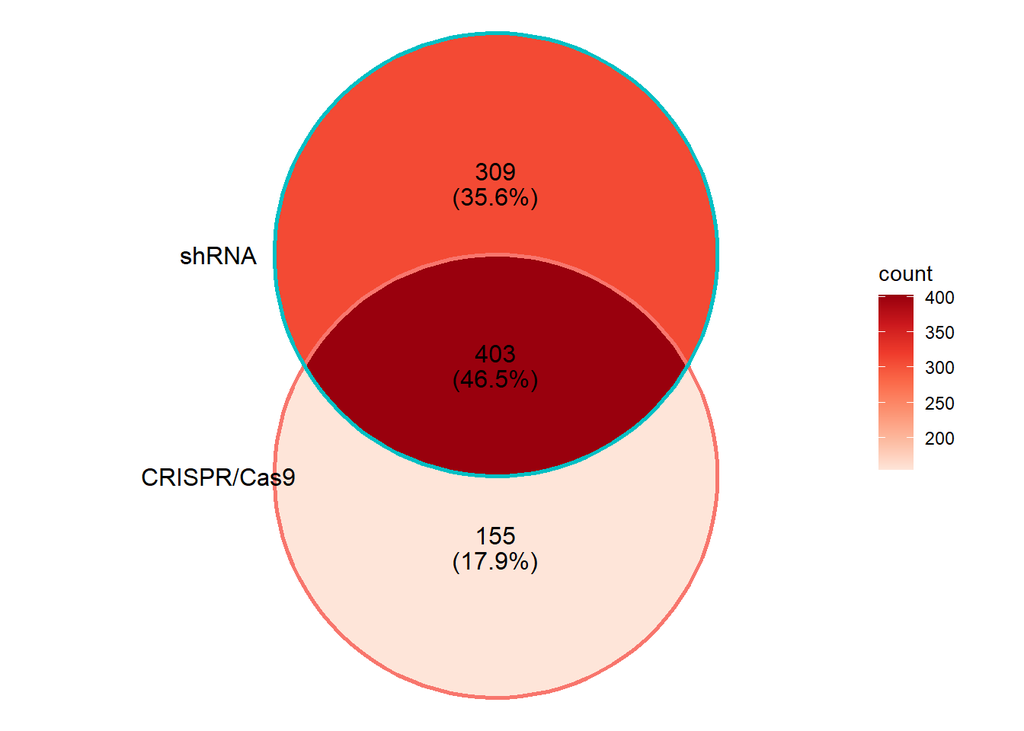

```r
ggsave("gene_venn.png",width = 4, height = 4)


# Plot Venn Diagram for Cell Lines
cell_venn = ggVennDiagram(x = list(CRISPR = cell_lines_crispr, shRNA = cell_lines_shrna),
              category.names = c("CRISPR/Cas9", "shRNA"),
              label = "both",
              label_percent_digit = 1,
              label_alpha = 0) +
  scale_fill_distiller(palette = "Reds", direction = 1) +
  scale_x_continuous(expand = expansion(mult = .3))

cell_venn
```

```r
ggsave("cell_venn.png",width = 4, height = 4)
```

## Fig 3 C-D

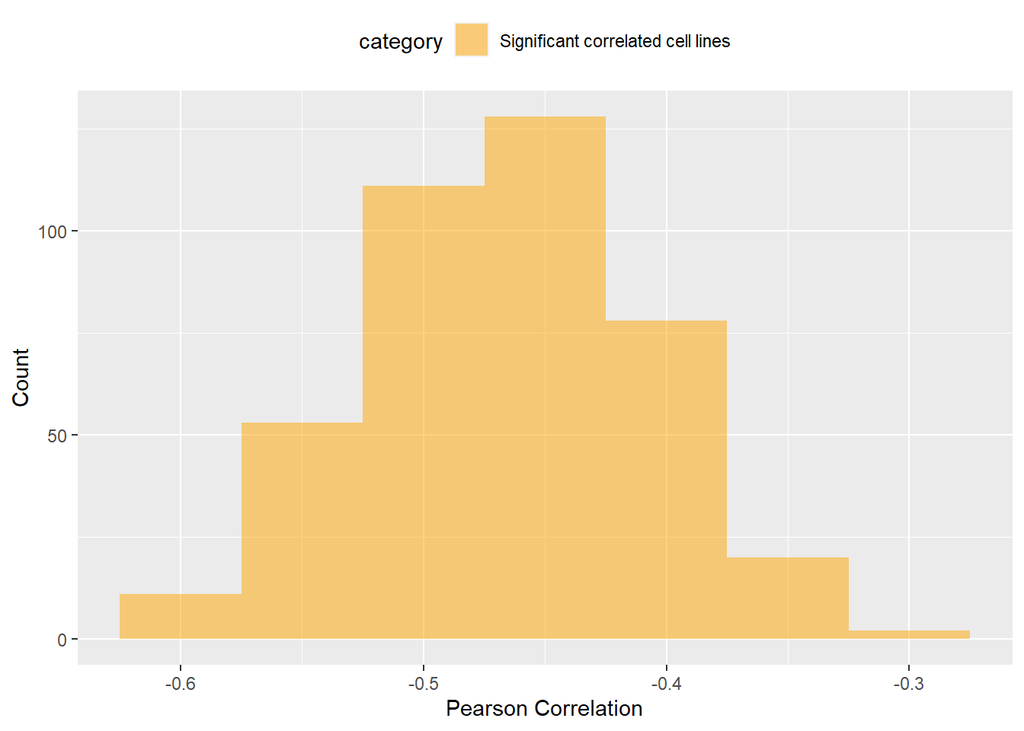

```r
# Get the common genes(in column)
intersection_cell = intersect(names(CRISPR_match), names(shRNA))
intersection_cell_CRISPR = CRISPR_match |> select(intersection_cell)
intersection_cell_shRNA = shRNA |> select(intersection_cell)

# Get the common cell lines(in row)
intersection_gene = intersect(intersection_cell_CRISPR$ccle_id, intersection_cell_shRNA$ccle_id)

# Get the two comparable datasets from CRISPR and shRNA
intersection_cell_CRISPR = intersection_cell_CRISPR |> filter(ccle_id %in% intersection_gene) |> arrange(ccle_id)
intersection_cell_shRNA = intersection_cell_shRNA |> filter(ccle_id %in% intersection_gene) |>arrange(ccle_id)
# 403 cell lines X 14915 genes


# Calculate correlations for cell lines (C)
cell_correlation = sapply(1:403, function(i) {
  cor.test(as.numeric(unlist(intersection_cell_shRNA[i,])), as.numeric(unlist(intersection_cell_CRISPR[i,])))|> broom::tidy() |> select(estimate, p.value) |> mutate(p_adjusted = p.adjust(p.value, method = "fdr", n = 403))
})

cell_correlation = cell_correlation |> t() |> as_tibble() |> unnest(estimate) |>
  mutate(category = ifelse(p.value < 0.01 & p_adjusted < 0.1 & abs(estimate) >= 0.3,"Significant correlated cell lines","All cell lines"))

# Plot Histogram for Correlations of Cell Lines (C)
corr_cell_plot = ggplot(cell_correlation, aes(x = estimate, fill = category)) +
  geom_histogram(binwidth = 0.05, alpha = 0.5) +
  scale_fill_manual(values = c("All cell lines" = "blue", "Significant correlated cell lines" = "orange")) +
  theme(legend.position = "top") +
  labs(x = "Pearson Correlation",
       y = "Count")

corr_cell_plot
```

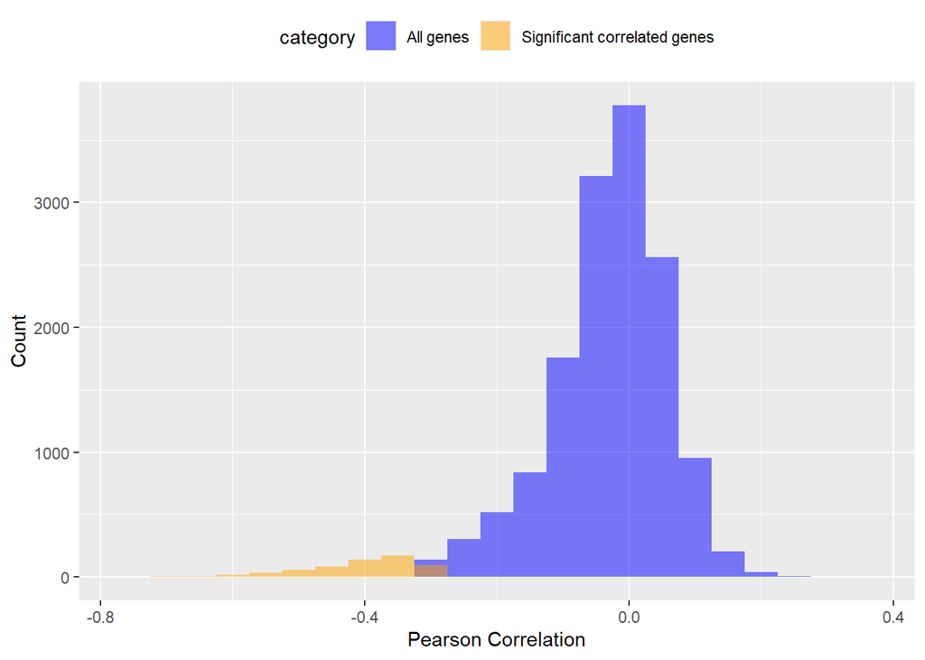

```r
ggsave("corr_cell_plot.png",width = 4, height = 4)


# Calculate correlations for genes (D)
gene_correlation = sapply(2:14916, function(i) {
  cor.test(as.numeric(unlist(intersection_cell_shRNA[,i])), as.numeric(unlist(intersection_cell_CRISPR[,i]))) |> broom::tidy() |> select(estimate, p.value) |> mutate(p_adjusted = p.adjust(p.value, method = "fdr", n = 14915))
})

gene_correlation = gene_correlation |> t() |> as_tibble() |> unnest(estimate) |>
  mutate(category = ifelse(p.value < 0.01 & p_adjusted < 0.1 & abs(estimate) >= 0.3,"Significant correlated genes","All genes"))



# Plot Histogram for Correlations of Genes (D)
corr_gene_plot = ggplot(gene_correlation, aes(x = estimate, fill = category)) +
  geom_histogram(position = "identity", binwidth = 0.05, alpha = 0.5) +
  scale_fill_manual(values = c("All genes" = "blue", "Significant correlated genes" = "orange")) +
  theme(legend.position = "top") +
  labs(x = "Pearson Correlation",
       y = "Count")

corr_gene_plot
```

```r
ggsave("corr_gene_plot.png",width = 4, height = 4)
```

## Predictors

### Clean RPPA

```r
# load RPPA data
RPPA = read_csv("data/CCLE_RPPA_20181003.csv")
# 214 protein markers across 899 cell lines
#import the gene-antibody lookup table, only keep the validated, unique pairs
gene_protein = read_csv("data/For_AbGeneMatch_CCLE_RPPA_Ab_info_20181226.csv") |>
  janitor::clean_names()|>
  filter(validation_status == "Validated",
         !str_detect(target_genes," ")) |>
  distinct(target_genes, .keep_all = TRUE)


# Convert lookup table to named vector
names_vector = setNames(gene_protein$target_genes, gene_protein$antibody_name)
# Rename columns in 'data'
colnames(RPPA) = names_vector[colnames(RPPA)]
#rename the first blank colname
colnames(RPPA)[1] = "ccle_id"
# get 10 genes of interest from the validated_tested, unique 115 genes
# since I can get 108 corresponding cancer dependency data, it's enough, I wan to select genes of interest here to simplify(varified genes without multiple matching with RPPA )
RPPA = RPPA[,!is.na(colnames(RPPA))]
RPPA = RPPA[,order(colnames(RPPA))] |> select(ccle_id,everything())
skim(RPPA)
```

Data summary

| Name | RPPA |
| --- | --- |
| Number of rows | 899 |
| Number of columns | 112 |
| _______________________ |  |
| Column type frequency: |  |
| character | 1 |
| numeric | 111 |
| ________________________ |  |
| Group variables | None |

**Variable type: character**

| skim_variable | n_missing | complete_rate | min | max | empty | n_unique | whitespace |
| --- | --- | --- | --- | --- | --- | --- | --- |
| ccle_id | 0 | 1 | 8 | 46 | 0 | 899 | 0 |

**Variable type: numeric**

| skim_variable | n_missing | complete_rate | mean | sd | p0 | p25 | p50 | p75 | p100 | hist |
| --- | --- | --- | --- | --- | --- | --- | --- | --- | --- | --- |
| ADAR | 0 | 1 | 0.03 | 0.40 | -1.06 | -0.25 | 0 | 0.29 | 1.59 | ▁▇▇▂▁ |
| AKT1S1 | 0 | 1 | 0.03 | 0.39 | -0.88 | -0.25 | 0 | 0.27 | 1.89 | ▃▇▃▁▁ |
| ANXA1 | 0 | 1 | -0.05 | 1.19 | -2.75 | -1.11 | 0 | 0.83 | 3.46 | ▃▆▇▃▁ |
| ANXA7 | 0 | 1 | 0.02 | 0.40 | -1.02 | -0.23 | 0 | 0.25 | 2.37 | ▂▇▂▁▁ |
| AR | 0 | 1 | 0.21 | 0.65 | -0.58 | -0.14 | 0 | 0.26 | 5.66 | ▇▁▁▁▁ |
| ASNS | 0 | 1 | -0.02 | 0.99 | -4.13 | -0.60 | 0 | 0.61 | 3.10 | ▁▁▇▆▁ |
| ATM | 0 | 1 | -0.08 | 0.91 | -4.92 | -0.52 | 0 | 0.44 | 2.68 | ▁▁▃▇▁ |
| BAD | 0 | 1 | 0.02 | 0.24 | -0.69 | -0.15 | 0 | 0.17 | 1.21 | ▁▇▅▁▁ |
| BAP1 | 0 | 1 | -0.05 | 0.43 | -2.27 | -0.23 | 0 | 0.21 | 1.40 | ▁▁▅▇▁ |
| BAX | 0 | 1 | 0.03 | 0.55 | -1.72 | -0.36 | 0 | 0.34 | 2.86 | ▁▇▆▁▁ |
| BCL2 | 0 | 1 | 0.32 | 0.99 | -1.21 | -0.34 | 0 | 0.65 | 4.58 | ▇▆▂▁▁ |
| BCL2L1 | 0 | 1 | 0.04 | 0.48 | -1.17 | -0.33 | 0 | 0.35 | 1.96 | ▂▇▆▂▁ |
| BCL2L11 | 0 | 1 | 0.03 | 1.08 | -3.19 | -0.66 | 0 | 0.67 | 3.91 | ▁▅▇▂▁ |
| BRAF | 0 | 1 | 0.01 | 0.48 | -1.72 | -0.30 | 0 | 0.31 | 1.78 | ▁▃▇▃▁ |
| C12orf5 | 0 | 1 | 0.09 | 0.48 | -0.81 | -0.20 | 0 | 0.24 | 3.32 | ▇▆▁▁▁ |
| CAV1 | 0 | 1 | 0.01 | 2.69 | -4.27 | -2.60 | 0 | 2.51 | 6.29 | ▇▃▅▆▁ |
| CCNB1 | 0 | 1 | -0.01 | 0.82 | -3.71 | -0.48 | 0 | 0.54 | 2.07 | ▁▁▅▇▂ |
| CCND1 | 0 | 1 | 0.06 | 0.40 | -1.01 | -0.19 | 0 | 0.24 | 2.16 | ▁▇▂▁▁ |
| CCNE1 | 0 | 1 | 0.07 | 0.58 | -1.59 | -0.27 | 0 | 0.37 | 3.68 | ▁▇▂▁▁ |
| CDH1 | 0 | 1 | 0.95 | 2.02 | -1.97 | -0.76 | 0 | 2.99 | 5.46 | ▇▅▂▆▂ |
| CDH2 | 0 | 1 | 0.03 | 0.46 | -0.87 | -0.35 | 0 | 0.34 | 2.33 | ▆▇▃▁▁ |
| CDK1 | 0 | 1 | 0.10 | 0.53 | -0.85 | -0.21 | 0 | 0.24 | 3.77 | ▇▅▁▁▁ |
| CDKN1A | 0 | 1 | 0.07 | 0.71 | -1.48 | -0.38 | 0 | 0.39 | 3.49 | ▂▇▂▁▁ |
| CDKN1B | 0 | 1 | 0.05 | 0.36 | -0.80 | -0.19 | 0 | 0.21 | 1.90 | ▂▇▂▁▁ |
| CHEK2 | 0 | 1 | 0.03 | 0.53 | -1.73 | -0.31 | 0 | 0.38 | 1.79 | ▁▃▇▃▁ |
| CLDN7 | 0 | 1 | 0.91 | 1.68 | -1.06 | -0.42 | 0 | 2.35 | 5.58 | ▇▂▂▂▁ |
| COL6A1 | 0 | 1 | 0.04 | 0.40 | -1.18 | -0.20 | 0 | 0.22 | 2.06 | ▁▇▃▁▁ |
| CTNNB1 | 0 | 1 | -0.04 | 0.60 | -1.62 | -0.52 | 0 | 0.41 | 1.56 | ▂▆▇▇▁ |
| DVL3 | 0 | 1 | 0.01 | 0.39 | -2.09 | -0.25 | 0 | 0.28 | 1.25 | ▁▁▇▇▁ |
| EEF2K | 0 | 1 | -0.01 | 0.61 | -2.43 | -0.38 | 0 | 0.38 | 1.90 | ▁▂▇▆▁ |

[output cut: 81 more lines]

```r
# Normalize data (important for linear regression)
preProcessNorm = preProcess(RPPA, method = c("range"))
RPPA = predict(preProcessNorm, RPPA)
skim(RPPA)
```

Data summary

| Name | RPPA |
| --- | --- |
| Number of rows | 899 |
| Number of columns | 112 |
| _______________________ |  |
| Column type frequency: |  |
| character | 1 |
| numeric | 111 |
| ________________________ |  |
| Group variables | None |

**Variable type: character**

| skim_variable | n_missing | complete_rate | min | max | empty | n_unique | whitespace |
| --- | --- | --- | --- | --- | --- | --- | --- |
| ccle_id | 0 | 1 | 8 | 46 | 0 | 899 | 0 |

**Variable type: numeric**

| skim_variable | n_missing | complete_rate | mean | sd | p0 | p25 | p50 | p75 | p100 | hist |
| --- | --- | --- | --- | --- | --- | --- | --- | --- | --- | --- |
| ADAR | 0 | 1 | 0.41 | 0.15 | 0 | 0.30 | 0.40 | 0.51 | 1 | ▁▇▇▂▁ |
| AKT1S1 | 0 | 1 | 0.33 | 0.14 | 0 | 0.23 | 0.32 | 0.41 | 1 | ▃▇▃▁▁ |
| ANXA1 | 0 | 1 | 0.43 | 0.19 | 0 | 0.26 | 0.44 | 0.58 | 1 | ▃▆▇▃▁ |
| ANXA7 | 0 | 1 | 0.31 | 0.12 | 0 | 0.23 | 0.30 | 0.37 | 1 | ▂▇▂▁▁ |
| AR | 0 | 1 | 0.13 | 0.10 | 0 | 0.07 | 0.09 | 0.13 | 1 | ▇▁▁▁▁ |
| ASNS | 0 | 1 | 0.57 | 0.14 | 0 | 0.49 | 0.57 | 0.66 | 1 | ▁▁▇▆▁ |
| ATM | 0 | 1 | 0.64 | 0.12 | 0 | 0.58 | 0.65 | 0.71 | 1 | ▁▁▃▇▁ |
| BAD | 0 | 1 | 0.37 | 0.13 | 0 | 0.28 | 0.36 | 0.45 | 1 | ▁▇▅▁▁ |
| BAP1 | 0 | 1 | 0.60 | 0.12 | 0 | 0.56 | 0.62 | 0.67 | 1 | ▁▁▅▇▁ |
| BAX | 0 | 1 | 0.38 | 0.12 | 0 | 0.30 | 0.38 | 0.45 | 1 | ▁▇▆▁▁ |
| BCL2 | 0 | 1 | 0.26 | 0.17 | 0 | 0.15 | 0.21 | 0.32 | 1 | ▇▆▂▁▁ |
| BCL2L1 | 0 | 1 | 0.39 | 0.15 | 0 | 0.27 | 0.37 | 0.49 | 1 | ▂▇▆▂▁ |
| BCL2L11 | 0 | 1 | 0.45 | 0.15 | 0 | 0.36 | 0.45 | 0.54 | 1 | ▁▅▇▂▁ |
| BRAF | 0 | 1 | 0.49 | 0.14 | 0 | 0.40 | 0.49 | 0.58 | 1 | ▁▃▇▃▁ |
| C12orf5 | 0 | 1 | 0.22 | 0.12 | 0 | 0.15 | 0.20 | 0.26 | 1 | ▇▆▁▁▁ |
| CAV1 | 0 | 1 | 0.41 | 0.25 | 0 | 0.16 | 0.40 | 0.64 | 1 | ▇▃▅▆▁ |
| CCNB1 | 0 | 1 | 0.64 | 0.14 | 0 | 0.56 | 0.64 | 0.74 | 1 | ▁▁▅▇▂ |
| CCND1 | 0 | 1 | 0.34 | 0.13 | 0 | 0.26 | 0.32 | 0.40 | 1 | ▁▇▂▁▁ |
| CCNE1 | 0 | 1 | 0.31 | 0.11 | 0 | 0.25 | 0.30 | 0.37 | 1 | ▁▇▂▁▁ |
| CDH1 | 0 | 1 | 0.39 | 0.27 | 0 | 0.16 | 0.27 | 0.67 | 1 | ▇▅▂▆▂ |
| CDH2 | 0 | 1 | 0.28 | 0.14 | 0 | 0.16 | 0.27 | 0.38 | 1 | ▆▇▃▁▁ |
| CDK1 | 0 | 1 | 0.21 | 0.11 | 0 | 0.14 | 0.18 | 0.24 | 1 | ▇▅▁▁▁ |
| CDKN1A | 0 | 1 | 0.31 | 0.14 | 0 | 0.22 | 0.30 | 0.38 | 1 | ▂▇▂▁▁ |
| CDKN1B | 0 | 1 | 0.32 | 0.13 | 0 | 0.23 | 0.30 | 0.38 | 1 | ▂▇▂▁▁ |
| CHEK2 | 0 | 1 | 0.50 | 0.15 | 0 | 0.40 | 0.49 | 0.60 | 1 | ▁▃▇▃▁ |
| CLDN7 | 0 | 1 | 0.30 | 0.25 | 0 | 0.10 | 0.16 | 0.51 | 1 | ▇▂▂▂▁ |
| COL6A1 | 0 | 1 | 0.38 | 0.12 | 0 | 0.30 | 0.36 | 0.43 | 1 | ▁▇▃▁▁ |
| CTNNB1 | 0 | 1 | 0.50 | 0.19 | 0 | 0.35 | 0.51 | 0.64 | 1 | ▂▆▇▇▁ |
| DVL3 | 0 | 1 | 0.63 | 0.12 | 0 | 0.55 | 0.63 | 0.71 | 1 | ▁▁▇▇▁ |
| EEF2K | 0 | 1 | 0.56 | 0.14 | 0 | 0.47 | 0.56 | 0.65 | 1 | ▁▂▇▆▁ |

[output cut: 81 more lines]

```r
# apply(RPPA[-1],1,qqnorm); apply(RPPA[-1],1,qqline) QQ-plot shows that using "range" methods can better transform RPPA to be more normalized compared with c("center","scale") methods

# or using PCA to reduce the dimension
```

# combine the datasets

```r
# Find the common column names between the selected RPPA data and CRISPR/Cas9 data
common_columns = intersect(names(RPPA), names(CRISPR_match))
CRISPR_match = CRISPR_match[,common_columns]
# data normalization for outcome data is not necessary for the three ml algorithms

# Find the common column names between the selected RPPA data and CRISPR/Cas9 data
common_columns2 = intersect(names(RPPA), names(shRNA))


# data normalization for outcome data is not necessary for the three ml algorithms


# rename RPPA colnames by adding "_RPPA"
colnames(RPPA)[-1] = paste0(colnames(RPPA)[-1],"_RPPA")
# rename CRISPR_match colnames by adding "_dependency"
colnames(CRISPR_match)[-1] = paste0(colnames(CRISPR_match)[-1],"_dependency")

RPPA_match = inner_join(RPPA, cell_match, by='ccle_id')
RPPA_CRISPR = inner_join(RPPA_match, CRISPR_match, by='ccle_id') |> arrange(ccle_id) |>
  select(ccle_id, everything(),-AR_RPPA,-dep_map_id) |>
  select(1,2:21,112:131)

# select more genes here-13 pairs
```

# Schema 2: Machine learning

## Initialize containers for results

```r
results_train = data.frame(gene = character(), model_type = character(), rmse = numeric(), r2 = numeric(), stringsAsFactors = FALSE)
results_test = data.frame(gene = character(), model_type = character(), rmse = numeric(), r2 = numeric(), stringsAsFactors = FALSE)
final_models = list()
write.csv(RPPA_CRISPR,"RPPA_CRISPR.csv")
```

# Iteration

```r
common_name = common_columns[2:21]
for (gene in common_name) {
  # Prepare data for the current gene
  gene_data = RPPA_CRISPR |> select(paste0(gene, "_RPPA"), paste0(gene, "_dependency"))
  colnames(gene_data) = c("RPPA", "dependency")
  set.seed(123)
  # Split data into training and testing sets
  trainIndex = createDataPartition(gene_data$dependency, p = 0.7, list = FALSE)
  data_train = gene_data[trainIndex, ]
  data_test = gene_data[-trainIndex, ]

  # Baseline model: average dependency score
  avg_dependency_train = mean(data_train$dependency)
  baseline_predictions_train = rep(avg_dependency_train, nrow(data_train))
  rmse_baseline_train = RMSE(baseline_predictions_train, data_train$dependency)

  avg_dependency_test = mean(data_test$dependency)
  baseline_predictions_test = rep(avg_dependency_test, nrow(data_test))
  rmse_baseline_test = RMSE(baseline_predictions_test, data_test$dependency)

  # Avoid overfitting
  control = trainControl(method="repeatedcv", number=10, repeats=10, summaryFunction=defaultSummary)

  # Train models
  model_lm_train = train(dependency ~ RPPA, data = data_train, method = "lm", trControl = control)
  model_rf_train = train(dependency ~ RPPA, data = data_train, method = "rf", trControl = control)
  model_crf_train = train(dependency ~ RPPA, data = data_train, method = "cforest", trControl = control)

  # Model evaluation

  # for training data
  predictions_lm_train = predict(model_lm_train, newdata = data_train)
  predictions_rf_train = predict(model_rf_train, newdata = data_train)
  predictions_crf_train = predict(model_crf_train, newdata = data_train)

  rmse_lm_train = RMSE(predictions_lm_train, data_train$dependency)
  rmse_rf_train = RMSE(predictions_rf_train, data_train$dependency)
  rmse_crf_train = RMSE(predictions_crf_train, data_train$dependency)

  r2_lm_train = R2(predictions_lm_train, data_train$dependency)
  r2_rf_train = R2(predictions_rf_train, data_train$dependency)
  r2_crf_train = R2(predictions_crf_train, data_train$dependency)

  #for testing data
  predictions_lm_test = predict(model_lm_train, newdata = data_test)
  predictions_rf_test = predict(model_rf_train, newdata = data_test)
  predictions_crf_test = predict(model_crf_train, newdata = data_test)

  rmse_lm_test = RMSE(predictions_lm_test, data_test$dependency)
  rmse_rf_test = RMSE(predictions_rf_test, data_test$dependency)
  rmse_crf_test = RMSE(predictions_crf_test, data_test$dependency)

  r2_lm_test = R2(predictions_lm_test, data_test$dependency)
  r2_rf_test = R2(predictions_rf_test, data_test$dependency)
  r2_crf_test = R2(predictions_crf_test, data_test$dependency)



  # Store results
  results_train = rbind(results_train, data.frame(gene = gene, model_type = "Baseline", rmse = rmse_baseline_train, r2 = 0))
  results_train = rbind(results_train, data.frame(gene = gene, model_type = "LM", rmse = rmse_lm_train, r2 = r2_lm_train))
  results_train = rbind(results_train, data.frame(gene = gene, model_type = "RF", rmse = rmse_rf_train, r2 = r2_rf_train))
  results_train = rbind(results_train, data.frame(gene = gene, model_type = "CRF", rmse = rmse_crf_train, r2 = r2_crf_train))
  results_test = rbind(results_test, data.frame(gene = gene, model_type = "Baseline", rmse = rmse_baseline_test, r2 = 0))
  results_test = rbind(results_test, data.frame(gene = gene, model_type = "LM", rmse = rmse_lm_test, r2 = r2_lm_test))
  results_test = rbind(results_test, data.frame(gene = gene, model_type = "RF", rmse = rmse_rf_test, r2 = r2_rf_test))
  results_test = rbind(results_test, data.frame(gene = gene, model_type = "CRF", rmse = rmse_crf_test, r2 = r2_crf_test))

  # Flag predictable dependencies and retrain the best model
  if (any(rmse_lm_test < rmse_baseline_test, rmse_rf_test < rmse_baseline_test, rmse_crf_test < rmse_baseline_test)) {
    r2_values = c(r2_lm_test, r2_rf_test, r2_crf_test)
    best_model_index = which.max(r2_values)
    best_model_type = c("LM", "RF", "CRF")[best_model_index]

    if (best_model_type == "LM") {
      final_models[[gene]] = lm(dependency ~ RPPA, data = gene_data)
    } else if (best_model_type == "RF") {
      final_models[[gene]] = randomForest(dependency ~ RPPA, data = gene_data)
    } else if (best_model_type == "CRF") {
      final_models[[gene]] = cforest(dependency ~ RPPA, data = gene_data)
    }
  }
}
```

# Figure 4

the plot in fig 4 aims to show the proportion of genes that can successfully predict cancer dependency in test data; I think the results of train data are shown to compare the behaviour of test data and train data, which indicate if there’s overfitting or underfitting.

I modified the iterration function to get “results_train” and “results_test”, which are the results generated by “best-model-identifying” function trained from train data(not the whole dataset).

## combine train_result and test_result in a long format

```r
compare = bind_rows(train = results_train, test = results_test, .id = "split")
```

## visulaization like fig 4

I tried to use traditional methods to compare the behavior of train data and test data for each model. But the plots are not good to interpreted due to sparsity of high dimension data and lack of statistical power(I only got 20 genes). But it seems that RF is overfitting….

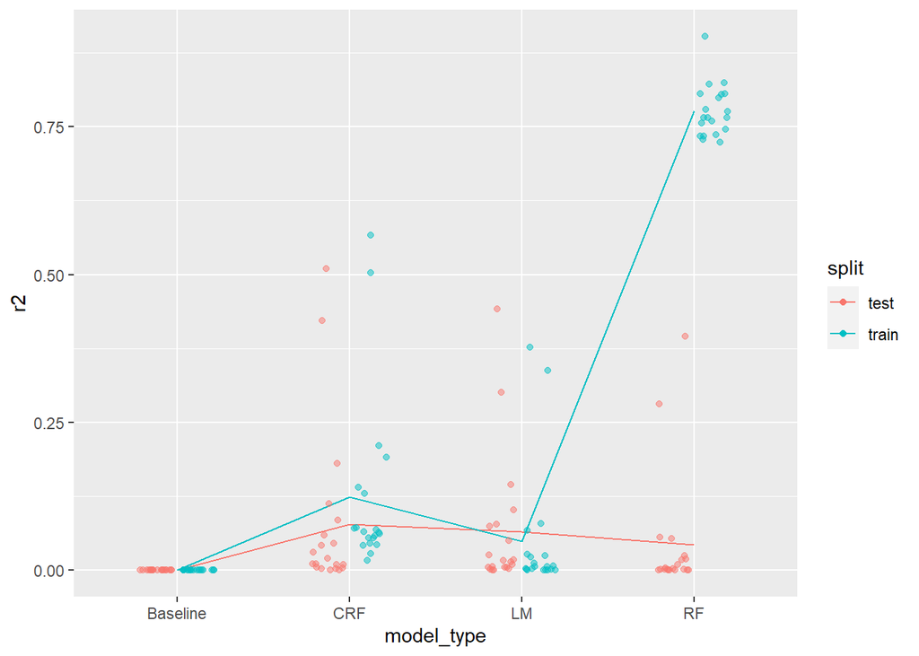

```r
compare |>
  ggplot(aes(x = model_type, y = r2, color = split, group = split)) +
  stat_summary(geom = "line", fun.y = "mean") +
  geom_point(
    position = position_jitterdodge(jitter.width = 0.2, dodge.width = 0.5),
    alpha = 0.5
  ) +
  ylim(0, NA) +
  guides(color = guide_legend(override.aes = list(alpha = 1)))
```

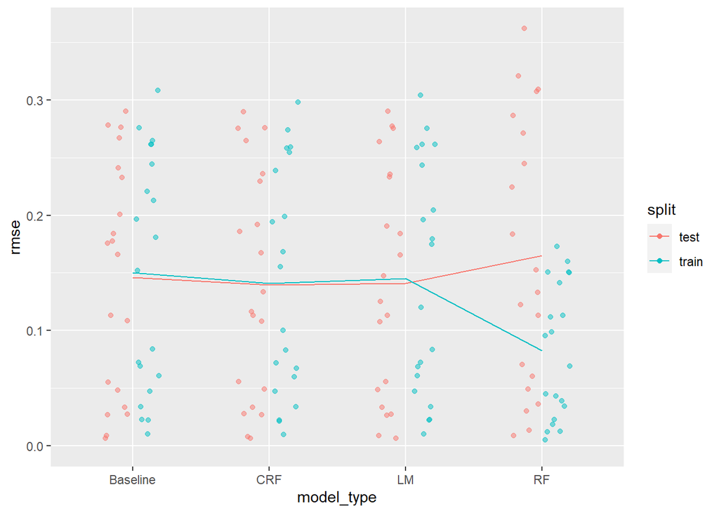

```r
compare |>
  ggplot(aes(x = model_type, y = rmse, color = split, group = split)) +
  stat_summary(geom = "line", fun.y = "mean") +
  geom_point(
    position = position_jitterdodge(jitter.width = 0.2, dodge.width = 0.5),
    alpha = 0.5
  ) +
  ylim(0, NA) +
  guides(color = guide_legend(override.aes = list(alpha = 1)))
```

## manipulate data and plot fig4

```r
# get the best model through r2

r2 = compare |>
  select(-rmse) |>
  group_by(split,gene) |>
  slice_max(r2) |>
  select(-r2) |>
  ungroup() |>
  group_by(split,model_type) |>
  summarise(count = n())
# get the best model through rmse

rmse = compare |>
  select(-r2) |>
  group_by(split,gene) |>
  slice_min(rmse) |>
  select(-rmse) |>
  ungroup() |>
  group_by(split,model_type) |>
  summarise(count = n())
```

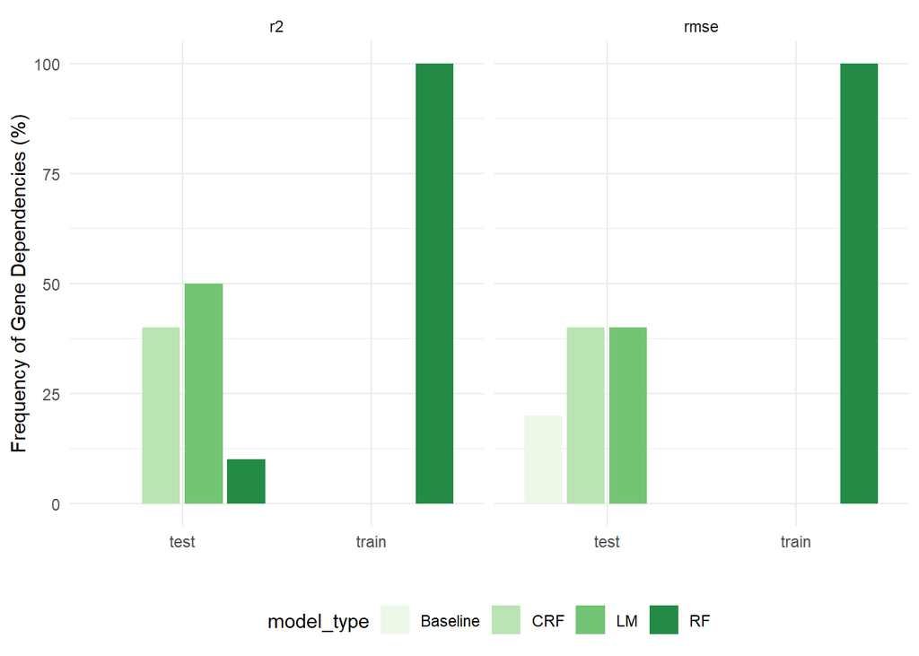

```r
# append the the two measurements results together

both = bind_rows(rmse = rmse, r2 = r2, .id = 'measurement')



# fill in the categories that have 0 count(not be selected as best model) to make sure every column has the same width.

supp1 = data.frame(measurement = c("rmse","r2"),
              split = "test",
              model_type = c("RF","Baseline"),
              count = 0)
supp2 = data.frame(measurement = "rmse",
              split = "train",
              model_type = c("Baseline","LM","CRF"),
              count = 0)
supp3 = data.frame(measurement = "r2",
              split = "train",
              model_type = c("Baseline","LM","CRF"),
              count = 0)
both = bind_rows(both,supp1,supp2,supp3)

fig4 = both |>
  mutate(count = (count/20)*100)|>
  ggplot(aes(x = split, y = count, fill = model_type)) +
  geom_bar(stat = "identity", position = position_dodge(width = 0.9),width = 0.8) +
  facet_grid( .~ measurement) +
  scale_fill_brewer(palette = "set1") +
  labs(x = "", y = "Frequency of Gene Dependencies (%)") +
  theme_minimal() +
  theme(legend.position = "bottom")
fig4
```

## Save the results

```r
ggsave("fig4.png")
```